# Logistic Regression

Dr. Cong Zhang

Logistic regression is a supervised **classification** model known as the **logit** model. It estimates the **probability** of something occurring, like 'will buy' or 'will not buy,' based on a dataset of independent variables. The outcome should be a categorical or a discrete value. The outcome can be either a 0 and 1, true and false, yes and no, and so on.

The model does not give an exact 0 and 1 but a value between 0 and 1. Unlike linear regression, which fits a regression line, logistic regression fits an 'S'-shaped logistic function (**Sigmoid function**).

In this document, we will learn how to implement logistic regression with sklearn in Python. Before we start, let's first import the needed libraries. We are going to use **Seaborn** for visualization, **NumPy**, and **Pandas** for data manipulation. Of course, the **sklearn** for the logistic regression model.

```python
import numpy as np
import pandas as pd
import matplotlib.pyplot as plt
import seaborn as sns
from sklearn.linear_model import LogisticRegression
```

The dataset we used for the demonstration is the social network ads dataset from Kaggle: https://www.kaggle.com/datasets/rakeshrau/social-network-ads?ref=mlnuggets. Let's build a logistic regression model to predict which customers will purchase or not purchase a product.

Run the following cell to import and take a look at the data:

```python
social_ads_data = pd.read_csv('https://raw.githubusercontent.com/CongZhangUbalt/data/main/social_net_ads.csv')
pd.concat([social_ads_data.head(), social_ads_data.tail()])
```

|  | User ID | Gender | Age | EstimatedSalary | Purchased |
| --- | --- | --- | --- | --- | --- |
| 0 | 15624510 | Male | 19 | 19000 | 0 |
| 1 | 15810944 | Male | 35 | 20000 | 0 |
| 2 | 15668575 | Female | 26 | 43000 | 0 |
| 3 | 15603246 | Female | 27 | 57000 | 0 |
| 4 | 15804002 | Male | 19 | 76000 | 0 |
| 395 | 15691863 | Female | 46 | 41000 | 1 |
| 396 | 15706071 | Male | 51 | 23000 | 1 |
| 397 | 15654296 | Female | 50 | 20000 | 1 |
| 398 | 15755018 | Male | 36 | 33000 | 0 |
| 399 | 15594041 | Female | 49 | 36000 | 1 |

Before moving on, let's visualize the data to get some overviews.

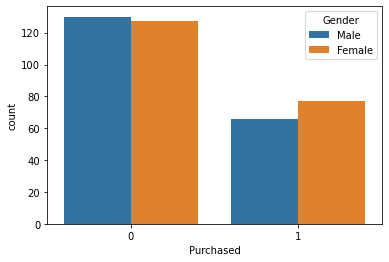

```python
# Check for how many males and females purchased the product:
sns.countplot(x='Purchased', hue='Gender', data=social_ads_data)
```

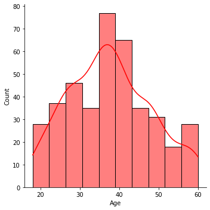

```python
# Check the age distribution in the dataset:
sns.displot(x='Age', data=social_ads_data, color='red', kde=True)
```

## Cleaning the data

We will use the *Gender, Age, and EstimatedSalary* columns from the dataset for the logistic regression. This means that we do not require the *UserID* column. Thus we will drop it.

```python
social_ads_data.drop('User ID', axis=1, inplace=True)
print(social_ads_data.head())
```

```
   Gender  Age  EstimatedSalary  Purchased
0    Male   19            19000          0
1    Male   35            20000          0
2  Female   26            43000          0
3  Female   27            57000          0
4    Male   19            76000          0
```

The *Gender* variable is categorical. For the model to work, we will convert it into dummy variables using the *oneHotEncoder* method. Also, we will standardize the numeric variables.

```python
# Data Cleaning
from sklearn.pipeline import Pipeline
from sklearn.preprocessing import StandardScaler
from sklearn.preprocessing import OneHotEncoder
from sklearn.compose import ColumnTransformer

social_ads_num = ['Age', 'EstimatedSalary']
social_ads_cat = ['Gender']
# Pipeline
clean_pipeline = ColumnTransformer([
        ("num", StandardScaler(), social_ads_num),
        ("cat", OneHotEncoder(), social_ads_cat),
])
socialads_prepared = clean_pipeline.fit_transform(social_ads_data)
print(socialads_prepared[:10])
```

```
[[-1.78179743 -1.49004624  0.          1.        ]
 [-0.25358736 -1.46068138  0.          1.        ]
 [-1.11320552 -0.78528968  1.          0.        ]
 [-1.01769239 -0.37418169  1.          0.        ]
 [-1.78179743  0.18375059  0.          1.        ]
 [-1.01769239 -0.34481683  0.          1.        ]
 [-1.01769239  0.41866944  1.          0.        ]
 [-0.54012675  2.35674998  1.          0.        ]
 [-1.20871865 -1.07893824  0.          1.        ]
 [-0.25358736 -0.13926283  1.          0.        ]]
```

```python
# Create X and y.
# Delete one dummy to avoid a perfect multicolinearity
X = np.delete(socialads_prepared,2,1)
# 'Purchased' is the target
y = social_ads_data['Purchased'].to_numpy()
```

```python
# Training and test sets split
from sklearn.model_selection import train_test_split
# Randomly sample our data --> 70% to train with, and 30% for testing
X_train, X_test, y_train, y_test = train_test_split(X, y, test_size=0.3)
print(X_train.shape)
print(X_test.shape)
print(y_train.shape)
print(y_test.shape)
```

```
(280, 3)
(120, 3)
(280,)
(120,)
```

## Fitting the logistic regression model

Now that the dataset is well prepared, we can train the model by importing the *LogisticRegression* class of the sklern *linear_model* module. Training is done by calling the *fit* method and pass the training data.

```python
from sklearn.linear_model import LogisticRegression
logit_reg = LogisticRegression()
logit_reg.fit(X_train, y_train)
```

```
LogisticRegression()
```

```python
# Print out the intercept and coefficients for the trained model.
print(logit_reg.intercept_, logit_reg.coef_)
print('intercept:',logit_reg.intercept_[0])
print('Age:', logit_reg.coef_[0][0])
print('EstimatedSalary:', logit_reg.coef_[0][1])
print('Male:', logit_reg.coef_[0][2])
```

```
[-1.04712544] [[2.28064792 1.05887366 0.0640413 ]]
intercept: -1.0471254413206095
Age: 2.2806479222414806
EstimatedSalary: 1.0588736565715282
Male: 0.06404130245369391
```

Based on the coefficients, we know that all three predictors positively affect a user's purchase probability.

Now, let's use cross-validation to evaluate our trained model's performance on the training set.

```python
from sklearn.model_selection import cross_val_score
#Get the evaluation scores (accuracy).
logit_reg_scores = cross_val_score(logit_reg, X_train, y_train,
                            scoring="accuracy", cv=10)
print("The average accuracy score is:",logit_reg_scores.mean())
```

```
The average accuracy score is: 0.8535714285714284
```

## Make Predictions

The model is now trained on the training set. Let's perform prediction on the test set using the *predict* method. Let's create a Pandas DataFrame and compare the predicted and actual values.

```python
y_pred = logit_reg.predict(X_test)
compare_table = pd.DataFrame({'Actual' : y_test, 'Predicted' : y_pred})
print(compare_table)
```

```
     Actual  Predicted
0         1          1
1         0          0
2         0          0
3         0          0
4         0          0
..      ...        ...
115       1          1
116       1          1
117       1          1
118       0          0
119       0          0

[120 rows x 2 columns]
```

```python
# Calculate the predictive accuracy
from sklearn.metrics import accuracy_score
pred_acc = accuracy_score(y_test, y_pred)
print("Model accuracy is {}%.".format(pred_acc*100))
```

```
Model accuracy is 85.0%.
```

# Exercise

In this exercise, we will work on the student grade dataset. Two predictors are *Self_Study_Daily" and "Tution_Monthly"*. *Self_Study_Daily* indicates how many hours the student studies daily at home, and *Tuition_Monthly* indicates how many hours per month the student is taking private tutor classes. The target variable *Pass_or_Fail* has two values 1 or 0, indicating a pass and a fail. Run the following cell to load the data and split it into training and test sets:

```python
student_grade = pd.read_csv('https://raw.githubusercontent.com/CongZhangUbalt/data/main/student_pass_fail.csv')
print(student_grade.head())
X = student_grade.drop('Pass_Or_Fail',axis = 1)
y = student_grade.Pass_Or_Fail
X_train, X_test, y_train, y_test = train_test_split(X, y, test_size=0.3)
```

```
   Self_Study_Daily  Tution_Monthly  Pass_Or_Fail
0                 7              27             1
1                 2              43             0
2                 7              26             1
3                 8              29             1
4                 3              42             0
```

## Question 1

Build and train a logistic regression model using the training data (*X_train, y_train*). **[2 points]** Display the intercept and coefficients for your trained logistic regression model. According to the coefficients, what is the relationship between the *Self_Study_Daily* and *Pass_Or_Fail*? **[2 points]**

```python
# Answer question 1 here:
from sklearn.linear_model import LogisticRegression

# Create a logistic regression object
logreg = LogisticRegression()

# Fit the model to the training data
logreg.fit(X_train, y_train)

# Display the intercept and coefficients
print("Intercept:", logreg.intercept_)
print("Coefficients:", logreg.coef_)


# What is the relationship between Self-Study_Daily and Pass_Or_Fail?
# ANS: More self study is assosoiciated with a higher probability of passing the exam.
# The baseline probability of passing the exam is represente by the intercept [7.50458743]
# The  effect of the features is in a range of [2.2506] to [-.78532]
```

```
Intercept: [7.50458743]
Coefficients: [[ 2.250641   -0.78532823]]
```

## Question 2

Run a 10-fold cross-validation on the trained model and print out the average acuracy value. **[3 points]**

```python
# Answer question 2 here:
from sklearn.model_selection import cross_val_score

# Perform 10-fold cross-validation on the trained model
scores = cross_val_score(logreg, X_train, y_train, cv=10)

# Print the average accuracy score
print("Average accuracy:", scores.mean())
```

```
Average accuracy: 0.9771428571428572
```

## Question 3

Test the trained model on the testing dataset (X_test and y_test) and print out the predictive accuracy. **[3 points]**

```python
# Answer question 3 here:
#Use the trained model to predict on the test data
y_pred = logreg.predict(X_test)
#Calculate the accuracy of the model on the test data
accuracy = (y_pred == y_test).mean()
#Print the accuracy
print("Predictive accuracy:", accuracy)
```

```
Predictive accuracy: 0.9733333333333334
```

# Submission

Once you finish all the excercise questions, check whether they all have outputs. Once you checked, save it as a HTML file and name it as "full name Exercise 8". Finally, submit it to Sakai.